# Assignment 2 - Time Series

## Questions

**What is your name? Include all team members if submitting as a group.**

- Archit Dudeja
- Shreeja Kapoor

**From what perspective are you conducting the analysis? (Who are you? / Who are you working for?)**

I'm an analyst hired by the Airline company to create an forecasting model using their historical data to predict ticket sales.

**What is your question?**

The main question I'm trying to answer is: Can we accurately forecast future monthly international airline passenger numbers based on historical data?

**Describe your dataset(s) including URL (if available).**

Dataset name: Air Passenger Data Source: https://www.kaggle.com/datasets/ashfakyeafi/air-passenger-data-for-time-series-analysis/data Brief description: Monthly totals of international airline passengers from 1949 to 1960 Size: 144 observations, 2 variables

**What is(are) your independent variable(s) and dependent variable(s)? Include variable type (binary, categorical, numeric). If you have many variables, you can list the most important and summarize the rest (e.g. important variables are... also, 12 other binary, 5 categorical...).**

Dependent Variable:

Name: #Passengers Type: Numeric

Independent Variable:

Name: Month Type: Date/Time

**How are your variables suitable for your analysis method?**

- The '#Passengers' variable is numeric and shows clear seasonal patterns and an upward trend, making it suitable for time-series model.
- The 'Month' variable provides the time component necessary for time series analysis, with regular monthly intervals.
- The dataset's length (144 months) provides sufficient data points for robust time series analysis and forecasting.

**What are your assumptions and limitations? What robustness checks did you perform or would you perform?**

- Assumptions:

The time series becomes stationary after seasonal differencing. Residuals are normally distributed and uncorrelated. The patterns observed in the historical data (1949-1960) will continue into the future.

- Limitations:

The model doesn't account for external factors that might influence passenger numbers (e.g., economic conditions, fuel prices, global events). The dataset only covers up to 1960, limiting its applicability to modern air travel patterns. The model assumes that the growth trend will continue indefinitely, which may not be realistic in the long term.

- Robustness Checks:

*Performed:*

- Augmented Dickey-Fuller test to confirm stationarity after differencing.
- Ljung-Box test to check for residual autocorrelation.
- Analysis of ACF and PACF plots to confirm appropriate model order.

*Would perform:*

- Cross-validation with different train-test splits to assess model stability.
- Comparison with other time series models (e.g., Prophet, exponential smoothing) to benchmark performance.
- Sensitivity analysis by varying the length of the training data to assess the model's dependence on historical patterns.

## Loading Packages & Data

```python
# Import necessary libraries
import pandas as pd
import numpy as np
import seaborn as sns
import matplotlib.pyplot as plt
from sklearn.model_selection import train_test_split
from sklearn.preprocessing import StandardScaler
import statsmodels.api as sm
from sklearn import tree
from sklearn import metrics
from sklearn.metrics import mean_absolute_error, mean_squared_error, r2_score
from statsmodels.tsa.seasonal import seasonal_decompose
from statsmodels.stats.diagnostic import acorr_ljungbox
from dateutil.parser import parse
import datetime
from statsmodels.tsa.stattools import adfuller
from statsmodels.graphics.tsaplots import plot_acf, plot_pacf
from statsmodels.tsa.arima.model import ARIMA
from statsmodels.graphics.tsaplots import plot_predict
from scipy import stats
!pip install pmdarima
import pmdarima as pm
from statsmodels.tsa.statespace.sarimax import SARIMAX
from math import sqrt
from pmdarima import auto_arima

# Load the dataset directly from a GitHub repository
data = 'https://raw.githubusercontent.com/ADudejaa/MachineLearning/refs/heads/main/AirPassengers.csv'
df = pd.read_csv(data, sep=',')

df.tail()
```

|  | Month | #Passengers |
| --- | --- | --- |
| 139 | 1960-08 | 606 |
| 140 | 1960-09 | 508 |
| 141 | 1960-10 | 461 |
| 142 | 1960-11 | 390 |
| 143 | 1960-12 | 432 |

## Exploratory Data Analysis

```python
df['Month'] = pd.to_datetime(df['Month'], format='%Y-%m')
df.info()
```

```
<class 'pandas.core.frame.DataFrame'>
RangeIndex: 144 entries, 0 to 143
Data columns (total 2 columns):
 #   Column       Non-Null Count  Dtype
---  ------       --------------  -----
 0   Month        144 non-null    datetime64[ns]
 1   #Passengers  144 non-null    int64
dtypes: datetime64[ns](1), int64(1)
memory usage: 2.4 KB
```

```python
df.set_index('Month', inplace=True)
```

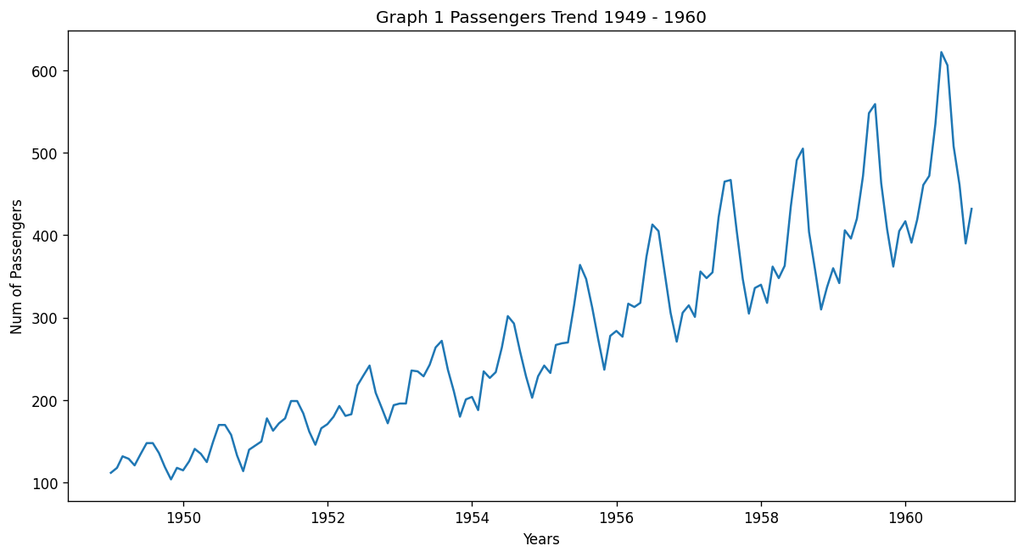

```python
plt.figure(figsize=(12,6))
plt.plot(df)
plt.xlabel('Years')
#plt.xticks(rotation=45)
plt.ylabel('Num of Passengers')
plt.title('Graph 1 Passengers Trend 1949 - 1960')
plt.show()
```

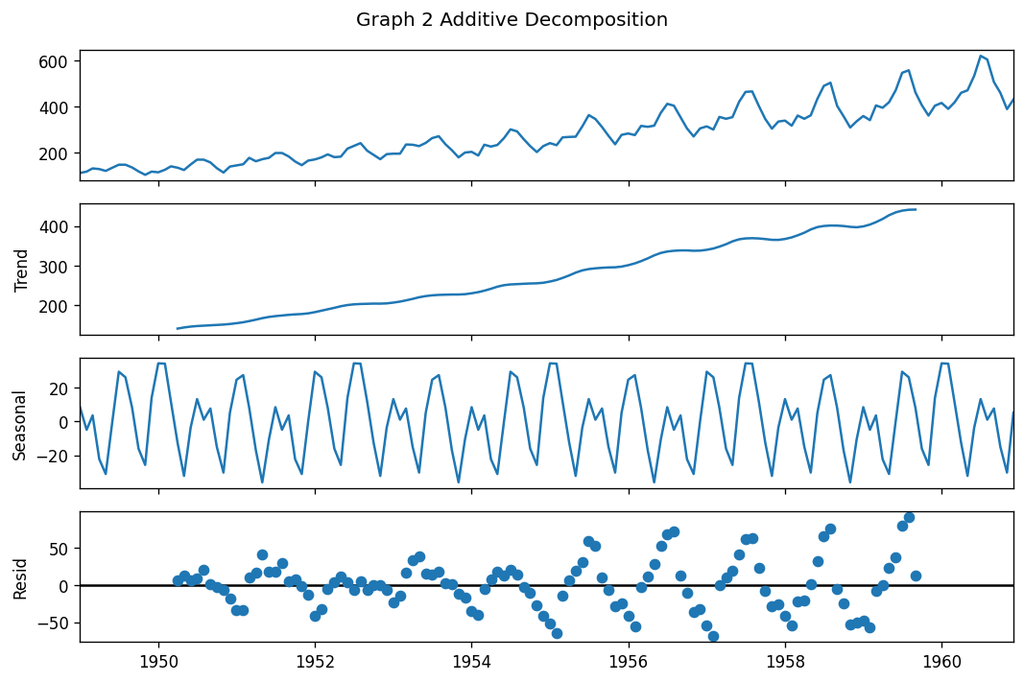

```python
additive_dec = seasonal_decompose(df, model='additive', period=30)
plt.figure(figsize=(12,8))
additive_dec.plot()
plt.suptitle('Graph 2 Additive Decomposition', fontsize=12)
plt.tight_layout()
plt.show()
```

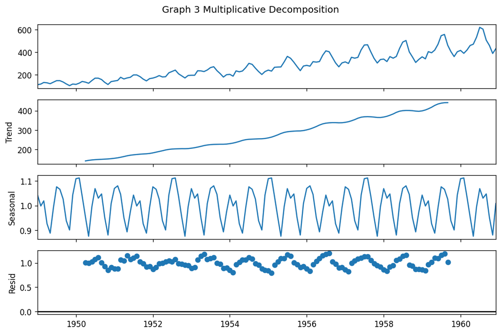

```python
multiplicative_dec = seasonal_decompose(df, model='multiplicative', period=30)
plt.figure(figsize=(12,8))
multiplicative_dec.plot()
plt.suptitle('Graph 3 Multiplicative Decomposition', fontsize=12)
plt.tight_layout()
plt.show()
```

## Stationary Test

Augmented Dickey-Fuller test

```python
result = adfuller(df.values)

# Create a DataFrame to display the results in table form
adf_output = pd.DataFrame({
    'Test Statistic': [result[0]],
    'p-value': [result[1]],
    'Lags Used': [result[2]],
    'Number of Observations': [result[3]],
    'Critical Value (1%)': [result[4]['1%']],
    'Critical Value (5%)': [result[4]['5%']],
    'Critical Value (10%)': [result[4]['10%']]
})
# Display the ADF test results
print(adf_output)
```

```
   Test Statistic  p-value  Lags Used  Number of Observations  \
0        0.815369  0.99188         13                     130

   Critical Value (1%)  Critical Value (5%)  Critical Value (10%)
0            -3.481682            -2.884042              -2.57877
```

```python
df2=df.copy()
df2['First_Difference'] = df['#Passengers'].diff()

result2 = adfuller(df2['First_Difference'].dropna())
# Create a DataFrame to display the results in table form
adf_output = pd.DataFrame({
    'Test Statistic': [result2[0]],
    'p-value': [result2[1]],
    'Lags Used': [result2[2]],
    'Number of Observations': [result2[3]],
    'Critical Value (1%)': [result2[4]['1%']],
    'Critical Value (5%)': [result2[4]['5%']],
    'Critical Value (10%)': [result2[4]['10%']]
})
# Display the ADF test results
print(adf_output)
```

```
   Test Statistic   p-value  Lags Used  Number of Observations  \
0       -2.829267  0.054213         12                     130

   Critical Value (1%)  Critical Value (5%)  Critical Value (10%)
0            -3.481682            -2.884042              -2.57877
```

```python
df2['S_Difference'] = df2['First_Difference'].diff()

result2 = adfuller(df2['S_Difference'].dropna())

adf_output = pd.DataFrame({
    'Test Statistic': [result2[0]],
    'p-value': [result2[1]],
    'Lags Used': [result2[2]],
    'Number of Observations': [result2[3]],
    'Critical Value (1%)': [result2[4]['1%']],
    'Critical Value (5%)': [result2[4]['5%']],
    'Critical Value (10%)': [result2[4]['10%']]
})
# Display the ADF test results
print(adf_output)
```

```
   Test Statistic       p-value  Lags Used  Number of Observations  \
0      -16.384232  2.732892e-29         11                     130

   Critical Value (1%)  Critical Value (5%)  Critical Value (10%)
0            -3.481682            -2.884042              -2.57877
```

We can see after 2nd differencing, the P values is less than 0.05 therefore d = 2

```python
# Assuming you have a time series called 'Second_Difference' for the differenced data

# Perform the Ljung-Box test on the differenced series
ljung_box_test = acorr_ljungbox(df2['S_Difference'].dropna(), lags=[10], return_df=True)

# Display the test results
print(ljung_box_test)
```

```
      lb_stat  lb_pvalue
10  37.566382   0.000045
```

p-value < 0.05, there is significant autocorrelation in the residuals, rejecting the null hypothesis.

We know we have to increase value of Q, P and D.

## Arima Q term

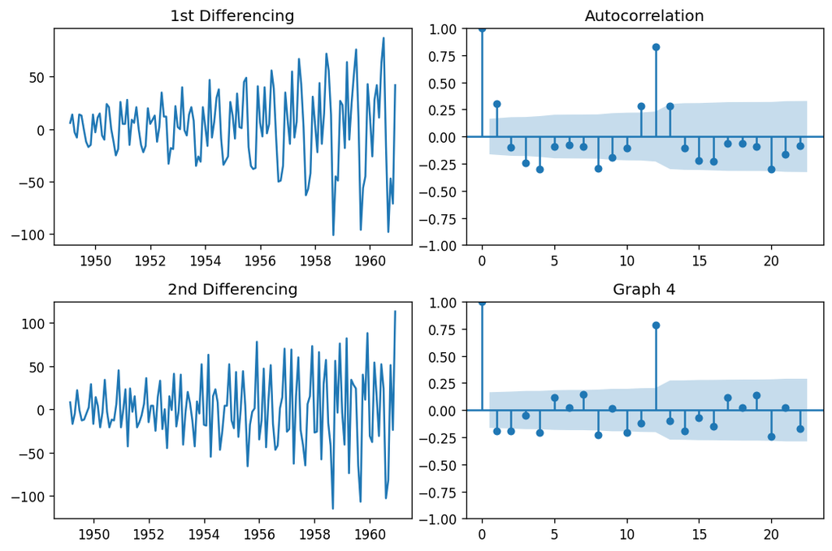

```python
plt.rcParams.update({'figure.figsize':(9,6), 'figure.dpi':120})

fig, axes = plt.subplots(2, 2, sharex=False)

# ACF plot of 1st differenced series
axes[0,0].plot(df.diff()); axes[0,0].set_title('1st Differencing')
axes[0,1].set(ylim=(0,5))
plot_acf(df.diff().dropna(), ax=axes[0,1])

# ACF plot of 2nd differenced series
axes[1,0].plot(df.diff().diff()); axes[1,0].set_title('2nd Differencing')
axes[1,1].set(ylim=(0,5))
plot_acf(df.diff().diff().dropna(), ax=axes[1,1])
plt.tight_layout()
plt.title('Graph 4')
plt.show()
```

Autocorrelation Function (ACF) plot.

The MA order would be 2 as there are two lag spikes in differencing.

## ARIMA p Term

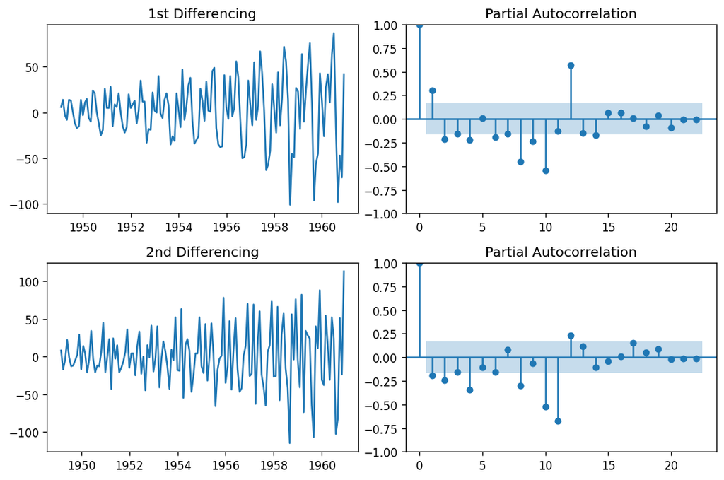

```python
plt.rcParams.update({'figure.figsize':(9,6), 'figure.dpi':120})

fig, axes = plt.subplots(2, 2, sharex=False)

# PACF plot of 1st differenced series
axes[0,0].plot(df.diff()); axes[0,0].set_title('1st Differencing')
axes[0,1].set(ylim=(0,5))
plot_pacf(df.diff().dropna(), ax=axes[0,1])

# PACF plot of 2nd differenced series
axes[1,0].plot(df.diff().diff()); axes[1,0].set_title('2nd Differencing')
axes[1,1].set(ylim=(0,5))
plot_pacf(df.diff().diff().dropna(), ax=axes[1,1])
plt.tight_layout()
plt.show()
```

Here we can see in 2nd differencing, the first lag is above limit. So select p = 1

## Fitting the Manual ARIMA

p= 1, d= 2, q= 2

```python
Arima = ARIMA(df, order=(1,2,2))
Ar = Arima.fit()
Ar.summary()
```

SARIMAX Results

| Dep. Variable: | #Passengers | No. Observations: | 144 |
| --- | --- | --- | --- |
| Model: | ARIMA(1, 2, 2) | Log Likelihood | -691.954 |
| Date: | Mon, 14 Oct 2024 | AIC | 1391.908 |
| Time: | 04:45:32 | BIC | 1403.732 |
| Sample: | 01-01-1949 | HQIC | 1396.713 |
|  | - 12-01-1960 |  |  |
| Covariance Type: | opg |  |  |

|  | coef | std err | z | P>\|z\| | [0.025 | 0.975] |
| --- | --- | --- | --- | --- | --- | --- |
| ar.L1 | -0.4710 | 0.123 | -3.838 | 0.000 | -0.711 | -0.230 |
| ma.L1 | -0.1369 | 18.236 | -0.008 | 0.994 | -35.879 | 35.605 |
| ma.L2 | -0.8631 | 15.736 | -0.055 | 0.956 | -31.705 | 29.979 |
| sigma2 | 965.2359 | 1.76e+04 | 0.055 | 0.956 | -3.36e+04 | 3.55e+04 |

| Ljung-Box (L1) (Q): | 0.18 | Jarque-Bera (JB): | 2.12 |
| --- | --- | --- | --- |
| Prob(Q): | 0.67 | Prob(JB): | 0.35 |
| Heteroskedasticity (H): | 6.99 | Skew: | -0.22 |
| Prob(H) (two-sided): | 0.00 | Kurtosis: | 3.42 |

Warnings:  
[1] Covariance matrix calculated using the outer product of gradients (complex-step).

## Auto ARIMA

```python
model = pm.auto_arima(df.values, start_p=1, start_q=1,
                      test='adf',       # use adftest to find optimal 'd'
                      max_p=5, max_q=5, # maximum p and q
                      m=1,              # frequency of series
                      d=None,           # let model determine 'd'
                      seasonal=False,   # No Seasonality
                      start_P=0,
                      D=0,
                      trace=True,
                      error_action='ignore',
                      suppress_warnings=True,
                      stepwise=True)

print(model.summary())
```

```
Performing stepwise search to minimize aic
 ARIMA(1,0,1)(0,0,0)[0]             : AIC=1412.973, Time=0.40 sec
 ARIMA(0,0,0)(0,0,0)[0]             : AIC=2057.847, Time=0.02 sec
 ARIMA(1,0,0)(0,0,0)[0]             : AIC=inf, Time=0.11 sec
 ARIMA(0,0,1)(0,0,0)[0]             : AIC=inf, Time=0.50 sec
 ARIMA(2,0,1)(0,0,0)[0]             : AIC=1410.569, Time=0.65 sec
 ARIMA(2,0,0)(0,0,0)[0]             : AIC=1417.450, Time=0.59 sec
 ARIMA(3,0,1)(0,0,0)[0]             : AIC=1411.319, Time=1.90 sec
 ARIMA(2,0,2)(0,0,0)[0]             : AIC=1411.135, Time=0.64 sec
 ARIMA(1,0,2)(0,0,0)[0]             : AIC=1413.093, Time=2.71 sec
 ARIMA(3,0,0)(0,0,0)[0]             : AIC=inf, Time=3.07 sec
 ARIMA(3,0,2)(0,0,0)[0]             : AIC=inf, Time=1.84 sec
 ARIMA(2,0,1)(0,0,0)[0] intercept   : AIC=1408.249, Time=0.69 sec
 ARIMA(1,0,1)(0,0,0)[0] intercept   : AIC=1409.748, Time=0.44 sec
 ARIMA(2,0,0)(0,0,0)[0] intercept   : AIC=1413.639, Time=0.45 sec
 ARIMA(3,0,1)(0,0,0)[0] intercept   : AIC=1408.287, Time=1.94 sec
 ARIMA(2,0,2)(0,0,0)[0] intercept   : AIC=1408.344, Time=2.71 sec
 ARIMA(1,0,0)(0,0,0)[0] intercept   : AIC=1428.179, Time=0.17 sec
 ARIMA(1,0,2)(0,0,0)[0] intercept   : AIC=1411.050, Time=2.05 sec
 ARIMA(3,0,0)(0,0,0)[0] intercept   : AIC=1410.342, Time=3.12 sec
 ARIMA(3,0,2)(0,0,0)[0] intercept   : AIC=inf, Time=2.87 sec

Best model:  ARIMA(2,0,1)(0,0,0)[0] intercept
Total fit time: 26.979 seconds
                               SARIMAX Results
==============================================================================
Dep. Variable:                      y   No. Observations:                  144
Model:               SARIMAX(2, 0, 1)   Log Likelihood                -699.125
Date:                Mon, 14 Oct 2024   AIC                           1408.249
Time:                        04:45:59   BIC                           1423.098
Sample:                             0   HQIC                          1414.283
                                - 144
Covariance Type:                  opg
==============================================================================
                 coef    std err          z      P>|z|      [0.025      0.975]
------------------------------------------------------------------------------
intercept     19.6007     12.051      1.627      0.104      -4.018      43.219
ar.L1          0.4990      0.131      3.822      0.000       0.243       0.755
ar.L2          0.4314      0.124      3.466      0.001       0.187       0.675
ma.L1          0.8565      0.081     10.540      0.000       0.697       1.016
sigma2       942.2492    107.314      8.780      0.000     731.917    1152.582
===================================================================================
Ljung-Box (L1) (Q):                   0.23   Jarque-Bera (JB):                 0.89
Prob(Q):                              0.63   Prob(JB):                         0.64
Heteroskedasticity (H):               6.30   Skew:                             0.16
Prob(H) (two-sided):                  0.00   Kurtosis:                         3.22
===================================================================================

Warnings:
[1] Covariance matrix calculated using the outer product of gradients (complex-step).
```

Our Manual ARIMA has a lower AIC then Auto Arima ( 1391 vs 1408).

## Split the Data

```python
# Create Training and Test
train_df = df.loc[:'1959']
test_df = df.loc['1960':]
```

```python
Arima = ARIMA(train_df, order=(1,2,2))
Ar = Arima.fit()
Ar.summary()
```

SARIMAX Results

| Dep. Variable: | #Passengers | No. Observations: | 132 |
| --- | --- | --- | --- |
| Model: | ARIMA(1, 2, 2) | Log Likelihood | -623.165 |
| Date: | Mon, 14 Oct 2024 | AIC | 1254.330 |
| Time: | 04:46:00 | BIC | 1265.800 |
| Sample: | 01-01-1949 | HQIC | 1258.991 |
|  | - 12-01-1959 |  |  |
| Covariance Type: | opg |  |  |

|  | coef | std err | z | P>\|z\| | [0.025 | 0.975] |
| --- | --- | --- | --- | --- | --- | --- |
| ar.L1 | -0.5412 | 0.100 | -5.435 | 0.000 | -0.736 | -0.346 |
| ma.L1 | -0.0727 | 4.777 | -0.015 | 0.988 | -9.436 | 9.290 |
| ma.L2 | -0.9269 | 4.446 | -0.208 | 0.835 | -9.641 | 7.787 |
| sigma2 | 819.0557 | 3945.052 | 0.208 | 0.836 | -6913.104 | 8551.215 |

| Ljung-Box (L1) (Q): | 0.29 | Jarque-Bera (JB): | 2.47 |
| --- | --- | --- | --- |
| Prob(Q): | 0.59 | Prob(JB): | 0.29 |
| Heteroskedasticity (H): | 6.79 | Skew: | -0.27 |
| Prob(H) (two-sided): | 0.00 | Kurtosis: | 3.41 |

Warnings:  
[1] Covariance matrix calculated using the outer product of gradients (complex-step).

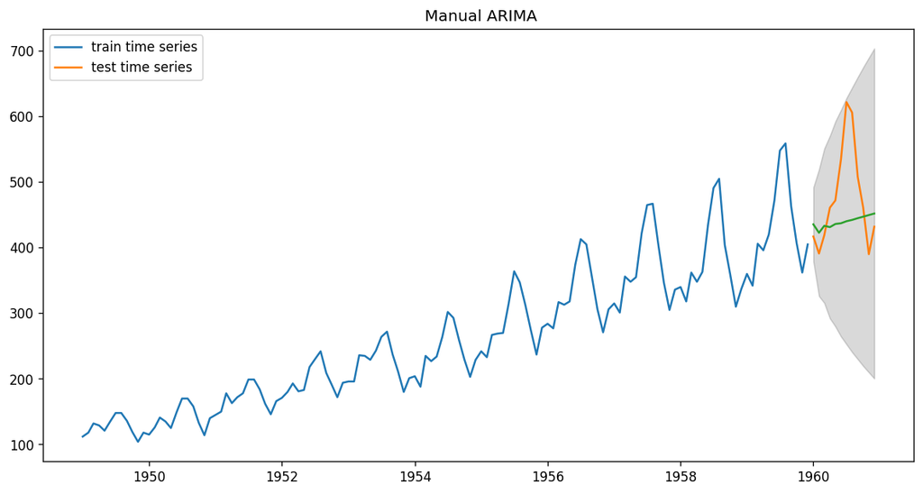

```python
# Forecast
fc = Ar.get_forecast(12).summary_frame()
fc = pd.DataFrame(fc).rename({'mean':'#Passengers'},axis=1)
fig, ax = plt.subplots(figsize=(12,6))
plt.plot(train_df, label='train time series')
plt.plot(test_df, label='test time series')
# plot_predict(Ar, '1956', '1962', ax=ax)
plt.plot(fc['#Passengers'])
plt.fill_between(fc.index, fc['mean_ci_lower'], fc['mean_ci_upper'],
                 color='k', alpha=.15)
plt.legend(loc='upper left')
plt.title(' Manual ARIMA')
plt.show()
```

## Auto Arima with Split dataset

```python
model = pm.auto_arima(train_df.values, start_p=1, start_q=1,
                      test='adf',
                      max_p=5, max_q=5, # maximum p and q
                      m=1,              # frequency of series
                      d=None,           # let model determine 'd'
                      seasonal=False,   # No Seasonality
                      start_P=0,
                      D=0,
                      trace=True,
                      error_action='ignore',
                      suppress_warnings=True,
                      stepwise=True)

print(model.summary())
```

```
Performing stepwise search to minimize aic
 ARIMA(1,0,1)(0,0,0)[0]             : AIC=1278.850, Time=0.36 sec
 ARIMA(0,0,0)(0,0,0)[0]             : AIC=1867.156, Time=0.02 sec
 ARIMA(1,0,0)(0,0,0)[0]             : AIC=inf, Time=0.13 sec
 ARIMA(0,0,1)(0,0,0)[0]             : AIC=inf, Time=0.12 sec
 ARIMA(2,0,1)(0,0,0)[0]             : AIC=1272.828, Time=0.68 sec
 ARIMA(2,0,0)(0,0,0)[0]             : AIC=1282.305, Time=0.21 sec
 ARIMA(3,0,1)(0,0,0)[0]             : AIC=1273.512, Time=1.90 sec
 ARIMA(2,0,2)(0,0,0)[0]             : AIC=1273.413, Time=0.37 sec
 ARIMA(1,0,2)(0,0,0)[0]             : AIC=1277.627, Time=0.15 sec
 ARIMA(3,0,0)(0,0,0)[0]             : AIC=inf, Time=0.14 sec
 ARIMA(3,0,2)(0,0,0)[0]             : AIC=inf, Time=0.45 sec
 ARIMA(2,0,1)(0,0,0)[0] intercept   : AIC=1270.547, Time=1.42 sec
 ARIMA(1,0,1)(0,0,0)[0] intercept   : AIC=1275.623, Time=0.93 sec
 ARIMA(2,0,0)(0,0,0)[0] intercept   : AIC=1278.559, Time=0.47 sec
 ARIMA(3,0,1)(0,0,0)[0] intercept   : AIC=1270.490, Time=2.30 sec
 ARIMA(3,0,0)(0,0,0)[0] intercept   : AIC=1276.127, Time=0.23 sec
 ARIMA(4,0,1)(0,0,0)[0] intercept   : AIC=1264.139, Time=2.89 sec
 ARIMA(4,0,0)(0,0,0)[0] intercept   : AIC=1274.874, Time=1.22 sec
 ARIMA(5,0,1)(0,0,0)[0] intercept   : AIC=1260.382, Time=1.08 sec
 ARIMA(5,0,0)(0,0,0)[0] intercept   : AIC=1270.195, Time=0.45 sec
 ARIMA(5,0,2)(0,0,0)[0] intercept   : AIC=1255.411, Time=2.83 sec
 ARIMA(4,0,2)(0,0,0)[0] intercept   : AIC=inf, Time=1.97 sec
 ARIMA(5,0,3)(0,0,0)[0] intercept   : AIC=inf, Time=3.99 sec
 ARIMA(4,0,3)(0,0,0)[0] intercept   : AIC=inf, Time=1.81 sec
 ARIMA(5,0,2)(0,0,0)[0]             : AIC=1257.960, Time=1.40 sec

Best model:  ARIMA(5,0,2)(0,0,0)[0] intercept
Total fit time: 27.630 seconds
                               SARIMAX Results
==============================================================================
Dep. Variable:                      y   No. Observations:                  132
Model:               SARIMAX(5, 0, 2)   Log Likelihood                -618.706
Date:                Mon, 14 Oct 2024   AIC                           1255.411
Time:                        04:46:29   BIC                           1281.356
Sample:                             0   HQIC                          1265.954
                                - 132
Covariance Type:                  opg
==============================================================================
                 coef    std err          z      P>|z|      [0.025      0.975]
------------------------------------------------------------------------------
intercept      1.2243      3.386      0.362      0.718      -5.412       7.860
ar.L1          1.1409      0.123      9.280      0.000       0.900       1.382
ar.L2          0.2413      0.171      1.407      0.159      -0.095       0.577
ar.L3         -0.6532      0.143     -4.563      0.000      -0.934      -0.373
ar.L4          0.0328      0.170      0.193      0.847      -0.299       0.365
ar.L5          0.2338      0.122      1.924      0.054      -0.004       0.472
ma.L1          0.1350      0.122      1.111      0.266      -0.103       0.373
ma.L2         -0.7316      0.137     -5.329      0.000      -1.001      -0.462
sigma2       683.2162    100.189      6.819      0.000     486.849     879.583
===================================================================================
Ljung-Box (L1) (Q):                   0.06   Jarque-Bera (JB):                 4.02
Prob(Q):                              0.81   Prob(JB):                         0.13
Heteroskedasticity (H):               5.99   Skew:                             0.42
Prob(H) (two-sided):                  0.00   Kurtosis:                         3.15
===================================================================================

Warnings:
[1] Covariance matrix calculated using the outer product of gradients (complex-step).
```

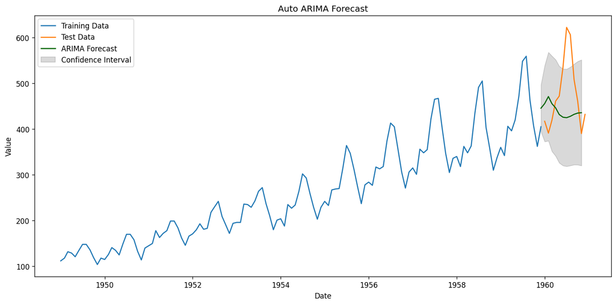

```python
# Forecast
n_periods = 12
fitted, confint = model.predict(n_periods=n_periods, return_conf_int=True)
index_of_fc = pd.date_range(train_df.index[-1], periods = n_periods, freq='MS')

# make series for plotting purpose
fitted_series = pd.Series(fitted, index=index_of_fc)
lower_series = pd.Series(confint[:, 0], index=index_of_fc)
upper_series = pd.Series(confint[:, 1], index=index_of_fc)

plt.figure(figsize=(12, 6))  # Increase figure size for better visibility

plt.plot(train_df, label='Training Data')
plt.plot(test_df, label='Test Data')
plt.plot(fitted_series, color='darkgreen', label='ARIMA Forecast')
plt.fill_between(lower_series.index,
                 lower_series,
                 upper_series,
                 color='k', alpha=.15, label='Confidence Interval')

plt.title("Auto ARIMA Forecast")
plt.xlabel("Date")
plt.ylabel("Value")

# Add legend
plt.legend(loc='best')

# Show plot
plt.tight_layout()
plt.show()
```

## Using ARIMAX

```
R-squared (R2): -1.7520
Mean Absolute Error (MAE): 115.3227
Root Mean Square Error (RMSE): 129.6122
Mean Absolute Percentage Error (MAPE): 29.0511%
Theil's U: 0.2898
```

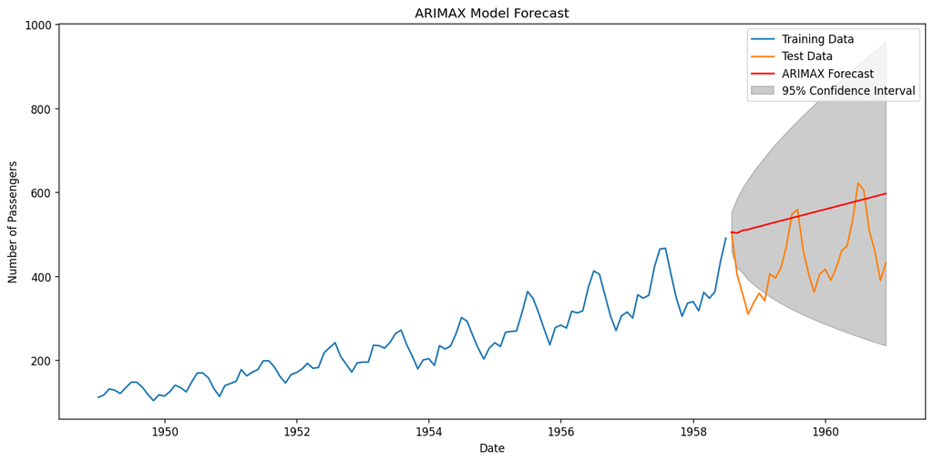

```
                               SARIMAX Results
==============================================================================
Dep. Variable:            #Passengers   No. Observations:                  115
Model:               SARIMAX(1, 2, 2)   Log Likelihood                -523.445
Date:                Mon, 14 Oct 2024   AIC                           1056.889
Time:                        04:46:31   BIC                           1070.526
Sample:                    01-01-1949   HQIC                          1062.423
                         - 07-01-1958
Covariance Type:                  opg
==============================================================================
                 coef    std err          z      P>|z|      [0.025      0.975]
------------------------------------------------------------------------------
trend         -0.0011   4.67e+04  -2.27e-08      1.000   -9.15e+04    9.15e+04
ar.L1         -0.5137      0.123     -4.173      0.000      -0.755      -0.272
ma.L1         -0.0843     13.817     -0.006      0.995     -27.166      26.998
ma.L2         -0.9155     12.627     -0.073      0.942     -25.664      23.833
sigma2       590.7307   8175.291      0.072      0.942   -1.54e+04    1.66e+04
===================================================================================
Ljung-Box (L1) (Q):                   0.10   Jarque-Bera (JB):                 2.31
Prob(Q):                              0.75   Prob(JB):                         0.31
Heteroskedasticity (H):               5.07   Skew:                             0.03
Prob(H) (two-sided):                  0.00   Kurtosis:                         2.30
===================================================================================

Warnings:
[1] Covariance matrix calculated using the outer product of gradients (complex-step).
```

```python
# Create an exogenous variable (trend)
df['trend'] = np.arange(len(df))

# Define your target variable
target = '#Passengers'

# Split the data into train and test sets
train_size = int(len(df) * 0.8)
train, test = df[:train_size], df[train_size:]

# Prepare the exogenous variables
train_exog = train[['trend']]
test_exog = test[['trend']]

# Define the ARIMAX order
order = (1, 2, 2)  # (p, d, q) - adjust based on your data

# Fit the ARIMAX model
model = SARIMAX(train[target], exog=train_exog, order=order)
resultsx = model.fit()

# Make predictions
pred = resultsx.get_forecast(steps=len(test), exog=test_exog)
pred_ci = pred.conf_int()

# Calculate performance metrics
mse = mean_squared_error(test[target], pred.predicted_mean)
rmse = sqrt(mse)
mae = mean_absolute_error(test[target], pred.predicted_mean)
r2 = r2_score(test[target], pred.predicted_mean)

print(f'R-squared (R2): {r2:.4f}')
print(f'Mean Absolute Error (MAE): {mae:.4f}')
print(f'Root Mean Square Error (RMSE): {rmse:.4f}')

# Calculate additional metrics
mape = np.mean(np.abs((test[target] - pred.predicted_mean) / test[target])) * 100
print(f'Mean Absolute Percentage Error (MAPE): {mape:.4f}%')

# Theil's U statistic
u = sqrt(np.sum((test[target] - pred.predicted_mean)**2) / np.sum(test[target]**2))
print(f"Theil's U: {u:.4f}")

# Plot the results
plt.figure(figsize=(12, 6))
plt.plot(train.index, train[target], label='Training Data')
plt.plot(test.index, test[target], label='Test Data')
plt.plot(pred.predicted_mean.index, pred.predicted_mean, color='r', label='ARIMAX Forecast')
plt.fill_between(pred_ci.index,
                 pred_ci.iloc[:, 0],
                 pred_ci.iloc[:, 1],
                 color='k', alpha=.2, label='95% Confidence Interval')

plt.title('ARIMAX Model Forecast')
plt.xlabel('Date')
plt.ylabel('Number of Passengers')
plt.legend(loc='best')
plt.tight_layout()
plt.show()

# Print model summary
print(resultsx.summary())
```

We can see the even arimax does not give a great prediction as it does not account for seasonality. AIC = 1056 which is better than arima but we can see the predictions from the graph

## Using SARIMA

To account for seasonality

```
Performing stepwise search to minimize aic
 ARIMA(0,0,0)(0,1,0)[12] intercept   : AIC=1022.234, Time=0.05 sec
 ARIMA(1,0,0)(1,1,0)[12] intercept   : AIC=906.857, Time=0.86 sec
 ARIMA(0,0,1)(0,1,1)[12] intercept   : AIC=963.555, Time=0.91 sec
 ARIMA(0,0,0)(0,1,0)[12]             : AIC=1192.711, Time=0.08 sec
 ARIMA(1,0,0)(0,1,0)[12] intercept   : AIC=907.180, Time=0.16 sec
 ARIMA(1,0,0)(2,1,0)[12] intercept   : AIC=908.543, Time=5.56 sec
 ARIMA(1,0,0)(1,1,1)[12] intercept   : AIC=inf, Time=2.25 sec
 ARIMA(1,0,0)(0,1,1)[12] intercept   : AIC=907.120, Time=0.43 sec
 ARIMA(1,0,0)(2,1,1)[12] intercept   : AIC=inf, Time=3.52 sec
 ARIMA(0,0,0)(1,1,0)[12] intercept   : AIC=1021.611, Time=0.36 sec
 ARIMA(2,0,0)(1,1,0)[12] intercept   : AIC=906.396, Time=0.65 sec
 ARIMA(2,0,0)(0,1,0)[12] intercept   : AIC=906.075, Time=0.18 sec
 ARIMA(2,0,0)(0,1,1)[12] intercept   : AIC=906.713, Time=0.47 sec
 ARIMA(2,0,0)(1,1,1)[12] intercept   : AIC=inf, Time=1.16 sec
 ARIMA(3,0,0)(0,1,0)[12] intercept   : AIC=905.686, Time=0.23 sec
 ARIMA(3,0,0)(1,1,0)[12] intercept   : AIC=906.124, Time=3.08 sec
 ARIMA(3,0,0)(0,1,1)[12] intercept   : AIC=906.388, Time=3.02 sec
 ARIMA(3,0,0)(1,1,1)[12] intercept   : AIC=906.035, Time=6.85 sec
 ARIMA(4,0,0)(0,1,0)[12] intercept   : AIC=907.453, Time=1.28 sec
 ARIMA(3,0,1)(0,1,0)[12] intercept   : AIC=907.583, Time=2.52 sec
 ARIMA(2,0,1)(0,1,0)[12] intercept   : AIC=906.399, Time=0.95 sec
 ARIMA(4,0,1)(0,1,0)[12] intercept   : AIC=909.320, Time=3.61 sec
 ARIMA(3,0,0)(0,1,0)[12]             : AIC=911.907, Time=0.15 sec

Best model:  ARIMA(3,0,0)(0,1,0)[12] intercept
Total fit time: 38.477 seconds
R-squared (R2): 0.9380
Mean Absolute Error (MAE): 14.8982
Root Mean Square Error (RMSE): 18.5365
Mean Absolute Percentage Error (MAPE): 3.0976%
Theil's U: 0.0385
```

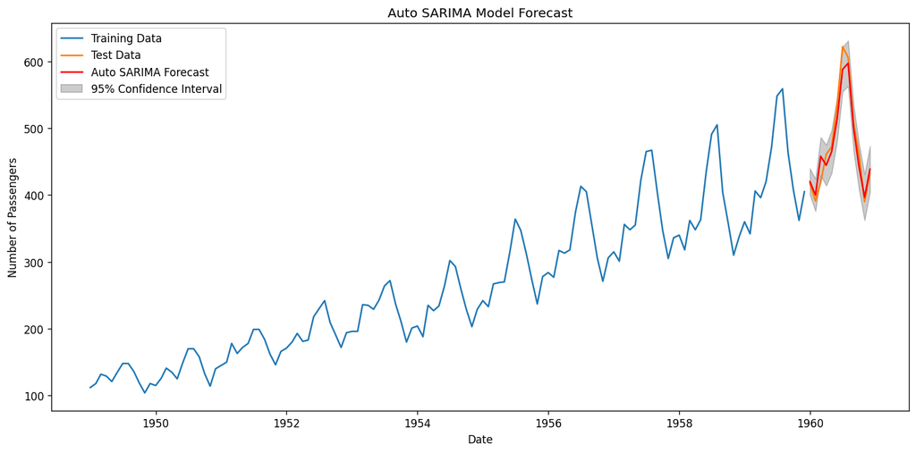

```
                                     SARIMAX Results
==========================================================================================
Dep. Variable:                                  y   No. Observations:                  132
Model:             SARIMAX(3, 0, 0)x(0, 1, 0, 12)   Log Likelihood                -447.843
Date:                            Mon, 14 Oct 2024   AIC                            905.686
Time:                                    04:47:10   BIC                            919.623
Sample:                                01-01-1949   HQIC                           911.346
                                     - 12-01-1959
Covariance Type:                              opg
==============================================================================
                 coef    std err          z      P>|z|      [0.025      0.975]
------------------------------------------------------------------------------
intercept      5.5341      2.007      2.757      0.006       1.600       9.468
ar.L1          0.7049      0.095      7.393      0.000       0.518       0.892
ar.L2          0.2574      0.131      1.968      0.049       0.001       0.514
ar.L3         -0.1434      0.107     -1.338      0.181      -0.354       0.067
sigma2       101.0969     12.818      7.887      0.000      75.974     126.220
===================================================================================
Ljung-Box (L1) (Q):                   0.00   Jarque-Bera (JB):                 2.83
Prob(Q):                              0.96   Prob(JB):                         0.24
Heteroskedasticity (H):               1.41   Skew:                            -0.14
Prob(H) (two-sided):                  0.29   Kurtosis:                         3.70
===================================================================================

Warnings:
[1] Covariance matrix calculated using the outer product of gradients (complex-step).
```

```python
# Fit the auto SARIMA model
smodel = pm.auto_arima(train_df[target], seasonal=True, m=12,
                   start_p=0, start_q=0, max_p=5, max_q=5, max_d=2,
                   start_P=0, start_Q=0, max_P=2, max_Q=2, max_D=1,
                   trace=True, error_action='ignore', suppress_warnings=True, stepwise=True)

target = '#Passengers'
# Make predictions
pred, conf_int = smodel.predict(n_periods=len(test_df), return_conf_int=True)

# Calculate performance metrics
mse = mean_squared_error(test_df[target], pred)
rmse = sqrt(mse)
mae = mean_absolute_error(test_df[target], pred)
r2 = r2_score(test_df[target], pred)

print(f'R-squared (R2): {r2:.4f}')
print(f'Mean Absolute Error (MAE): {mae:.4f}')
print(f'Root Mean Square Error (RMSE): {rmse:.4f}')

# Calculate additional metrics
mape = np.mean(np.abs((test_df[target].values - pred) / test_df[target].values)) * 100
print(f'Mean Absolute Percentage Error (MAPE): {mape:.4f}%')

# Theil's U statistic
u = sqrt(np.sum((test_df[target].values - pred)**2) / np.sum(test_df[target].values**2))
print(f"Theil's U: {u:.4f}")

# Plot the results
plt.figure(figsize=(12, 6))
plt.plot(train_df.index, train_df[target], label='Training Data')
plt.plot(test_df.index, test_df[target], label='Test Data')
plt.plot(test_df.index, pred, color='r', label='Auto SARIMA Forecast')
plt.fill_between(test_df.index,
                 conf_int[:, 0],
                 conf_int[:, 1],
                 color='k', alpha=.2, label='95% Confidence Interval')

plt.title('Auto SARIMA Model Forecast')
plt.xlabel('Date')
plt.ylabel('Number of Passengers')
plt.legend(loc='best')
plt.tight_layout()
plt.show()

# Print model summary
print(smodel.summary())
```

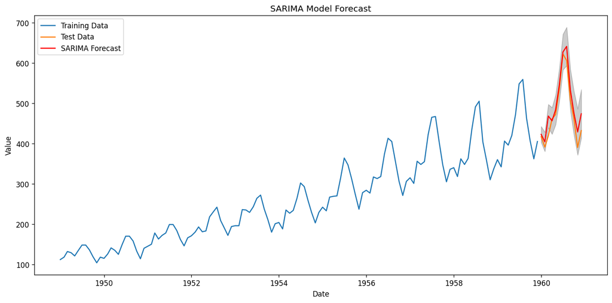

```
                                     SARIMAX Results
==========================================================================================
Dep. Variable:                        #Passengers   No. Observations:                  132
Model:             SARIMAX(1, 2, 2)x(1, 2, 2, 12)   Log Likelihood                -408.011
Date:                            Mon, 14 Oct 2024   AIC                            830.021
Time:                                    04:47:24   BIC                            848.665
Sample:                                01-01-1949   HQIC                           837.578
                                     - 12-01-1959
Covariance Type:                              opg
==============================================================================
                 coef    std err          z      P>|z|      [0.025      0.975]
------------------------------------------------------------------------------
ar.L1         -0.4289      0.298     -1.438      0.150      -1.013       0.156
ma.L1         -0.9172      1.792     -0.512      0.609      -4.429       2.594
ma.L2         -0.0813      0.380     -0.214      0.830      -0.826       0.663
ar.S.L12      -0.9735      0.127     -7.686      0.000      -1.222      -0.725
ma.S.L12      -0.0978     79.324     -0.001      0.999    -155.570     155.375
ma.S.L24      -0.9015     71.618     -0.013      0.990    -141.270     139.468
sigma2        88.2741   6995.234      0.013      0.990   -1.36e+04    1.38e+04
===================================================================================
Ljung-Box (L1) (Q):                   0.00   Jarque-Bera (JB):                 0.25
Prob(Q):                              0.94   Prob(JB):                         0.88
Heteroskedasticity (H):               1.05   Skew:                            -0.07
Prob(H) (two-sided):                  0.88   Kurtosis:                         2.81
===================================================================================

Warnings:
[1] Covariance matrix calculated using the outer product of gradients (complex-step).
```

```python
# Manual SARIMA

order = (1, 2, 2)  # (p, d, q)
seasonal_order = (1, 2, 2, 12)  # (P, D, Q, s) - assuming monthly data with yearly seasonality

# Fit the SARIMA model
model = SARIMAX(train_df, order=order, seasonal_order=seasonal_order)
results = model.fit()

# Make predictions
pred = results.get_forecast(steps=len(test_df))
pred_ci = pred.conf_int()


# Plot the results
plt.figure(figsize=(12, 6))
plt.plot(train_df.index, train_df, label='Training Data')
plt.plot(test_df.index, test_df, label='Test Data')
plt.plot(pred.predicted_mean.index, pred.predicted_mean, color='r', label='SARIMA Forecast')
plt.fill_between(pred_ci.index,
                 pred_ci.iloc[:, 0],
                 pred_ci.iloc[:, 1],
                 color='k', alpha=.2)

plt.title('SARIMA Model Forecast')
plt.xlabel('Date')
plt.ylabel('Value')
plt.legend(loc='best')
plt.tight_layout()
plt.show()

# Print model summary
print(results.summary())
```

We can see that the Manual SARIMA has the lowest AIC ( 830)

```python
!cp "/content/drive/MyDrive/Colab Notebooks/TimeSeries.ipynb" ./
!jupyter nbconvert --to html "TimeSeries.ipynb"
```

[output not shown]

[output cut: 134 more lines]

[output not shown]